# Packages

### ROC plot

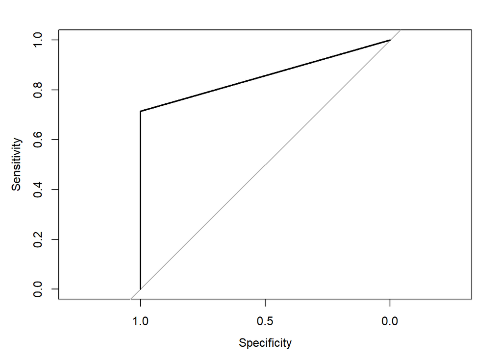

```r
roc_lda <- plot.roc(as.numeric(preds$class),
                    as.numeric(dat[test, "ML"]) )
```

### Cross-validation

Cross-validation is a resampling technique used to assess the performance and generalization ability of a predictive model.

#### 10-fold cross validation (One time):

```r
control <- trainControl(method = "cv", number = 10)

fit.lda <- train(ML~., data = dat, method = "lda",
                 metric = "Accuracy", trControl = control)
fit.rf <- train(ML~., data = dat, method = "rf",
                metric = "Accuracy", trControl = control)

results <- resamples(list(LDA = fit.lda, RF = fit.rf))
summary(results)
```

```
##
## Call:
## summary.resamples(object = results)
##
## Models: LDA, RF
## Number of resamples: 10
##
## Accuracy
##     Min. 1st Qu. Median  Mean 3rd Qu. Max. NA's
## LDA 0.75    0.75  0.875 0.875       1    1    0
## RF  0.50    0.75  0.875 0.850       1    1    0
##
## Kappa
##     Min. 1st Qu. Median Mean 3rd Qu. Max. NA's
## LDA  0.5     0.5   0.75 0.75       1    1    0
## RF   0.0     0.5   0.75 0.70       1    1    0
```

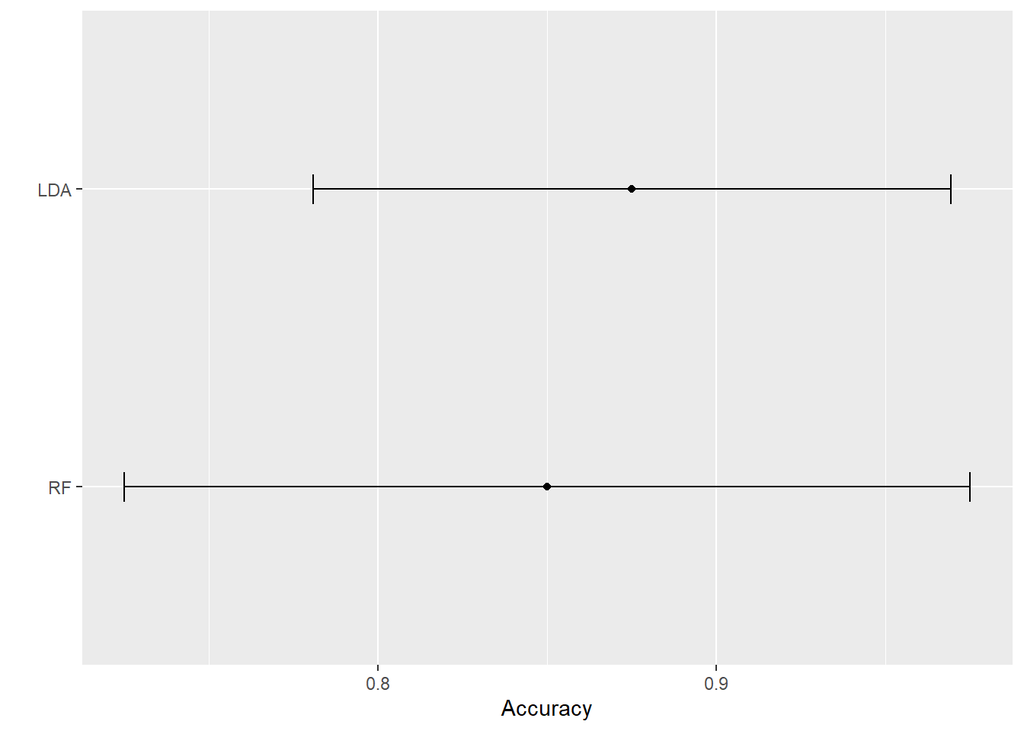

```r
ggplot(results) + labs(y = "Accuracy")
```

#### 10-fold cross validation (Ten times):

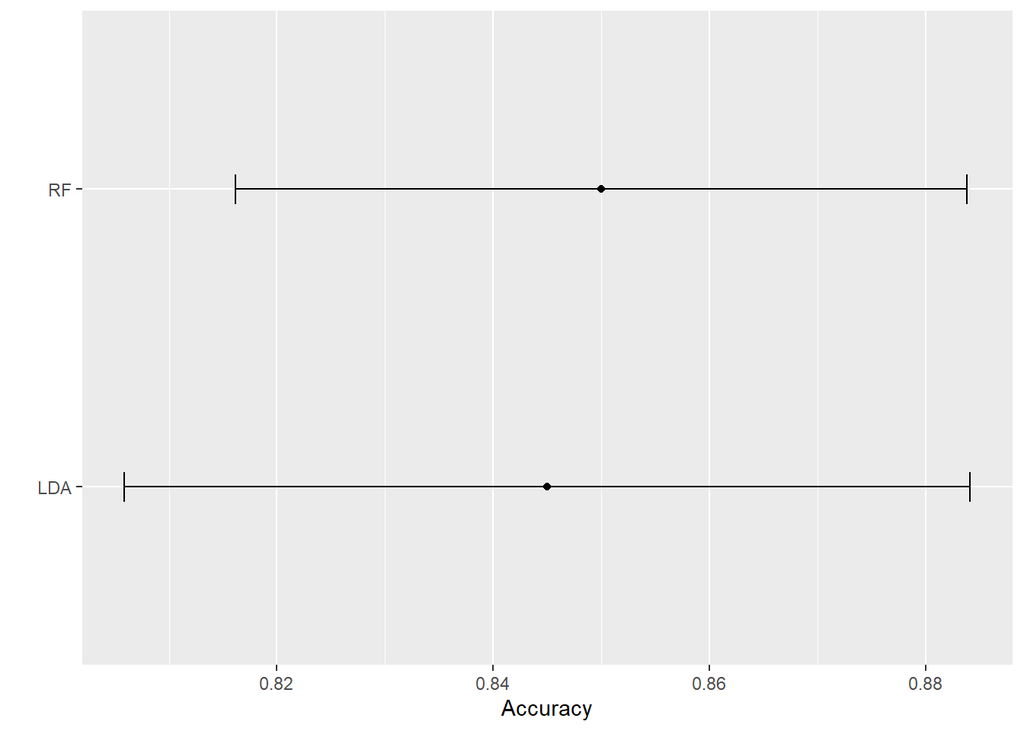

```r
metric = "Accuracy"

control <- trainControl(method = "repeatedcv", number = 10, repeats = 10)

fit.lda.2 <- train(ML~., data = dat, method = "lda",
                   metric = metric, trControl = control)

fit.rf.2 <- train(ML~., data = dat, method = "rf",
                  metric = metric, trControl = control)

results <- resamples(list(LDA = fit.lda.2, RF = fit.rf.2))
ggplot(results) + labs(y = "Accuracy")
```

## GLM

### First round

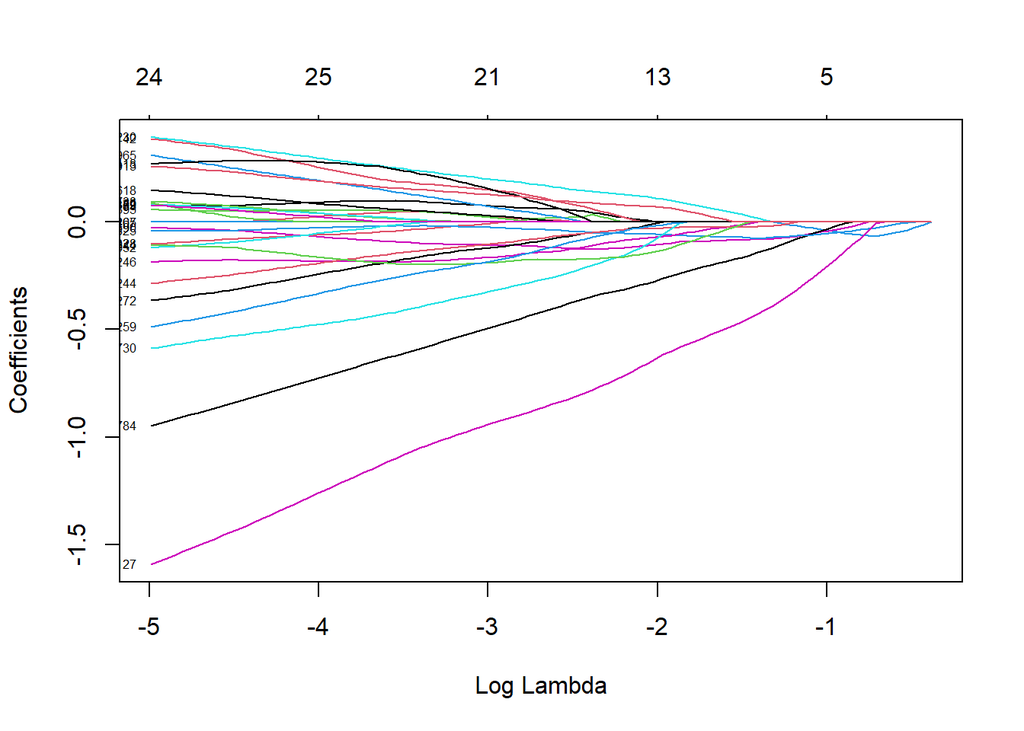

```r
ex3 <- ex2[, 1:40]
dat <- t(ex3)
y <- c(rep(0, 20), rep(1, 20))
f <- factor(y)

fit = glmnet(dat, y, standardize = FALSE, family = "binomial")
plot(fit, xvar = "lambda", label = TRUE)
```

The GLM is trained on a subset of the data using the data matrix “dat” as input features and the response variable “y” as the binary class labels. The graph shows the coefficients of the GLM as a function of the regularization parameter lambda.

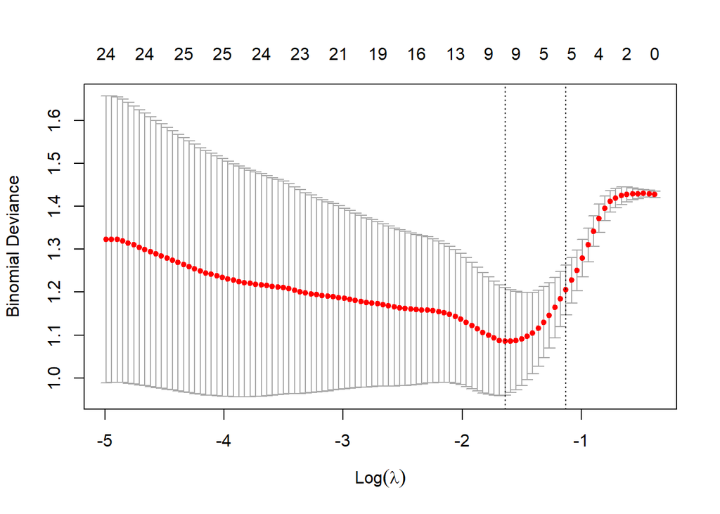

```r
cfit = cv.glmnet(dat, y, standardize = FALSE, family = "binomial")
plot(cfit)
```

The binomial deviance measures how well is the fit of GLM.

A smaller value of the binomial deviance indicates a better fit of the model to the data, while a larger value indicates a worse fit.

```r
summary(coef(cfit, s = cfit$lambda.min))
```

| i | j | x |
| --- | --- | --- |
| 1 | 1 | 7.39056894 |
| 14691 | 1 | -0.08703724 |
| 14785 | 1 | -0.19076239 |
| 15826 | 1 | -0.06859126 |
| 16247 | 1 | -0.02717690 |
| 17245 | 1 | -0.02341908 |
| 26128 | 1 | -0.50958935 |
| 35245 | 1 | -0.04715032 |
| 39231 | 1 | 0.05876582 |
| 45014 | 1 | 0.01848838 |

### Repeating analysis by using train + test sample subsets

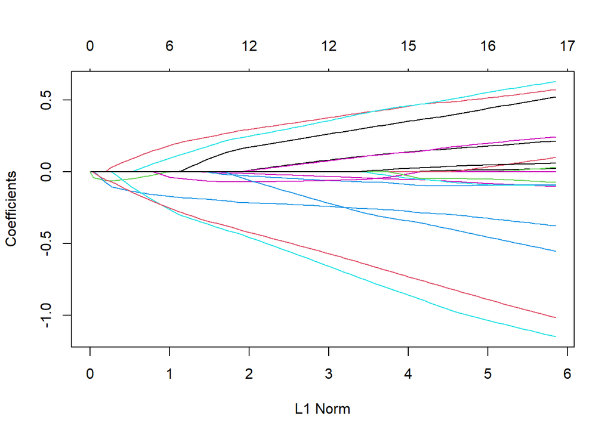

```r
n.dols <- 20
n.ins <- 20

train <- sample(1:(n.dols), (n.dols - 5))

test <- setdiff(1:(n.dols), train)
test <- c(test, test + 20)

train <- c(train, train + 20)

fit = glmnet(dat[train, ], y[train], standardize = FALSE, family = "binomial")
plot(fit)
```

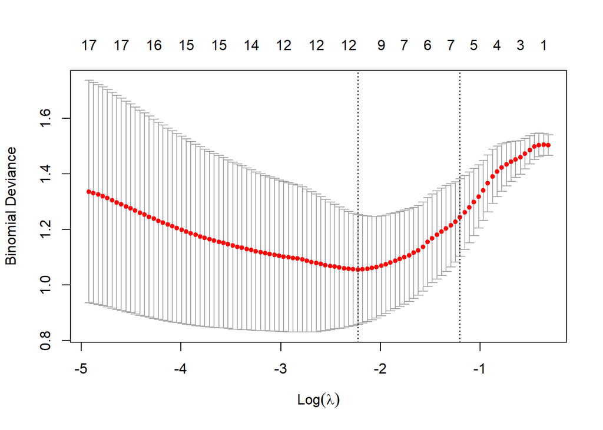

```r
cfit = cv.glmnet(dat[train, ], y[train], standardize = FALSE, family = "binomial")
plot(cfit)
```

```r
predict(fit, dat[test, ], type = "class", s = cfit$lambda.min)
```

```
##            s1
## GSM1060914 "0"
## GSM1060917 "0"
## GSM1060920 "1"
## GSM1060925 "1"
## GSM1060928 "0"
## GSM1060934 "1"
## GSM1060938 "1"
## GSM1060941 "0"
## GSM1060946 "1"
## GSM1060949 "1"
```

### ROCR

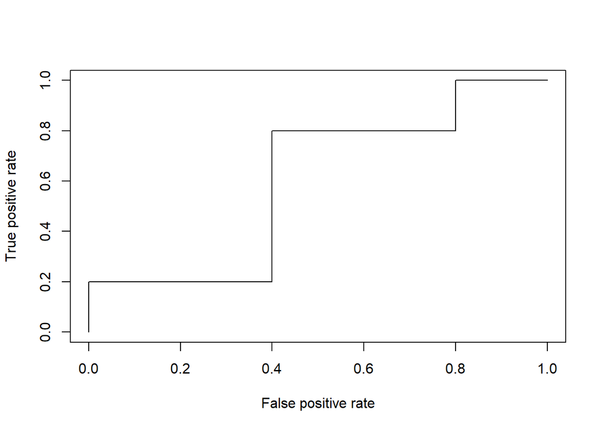

```r
pred2 <- predict(fit, dat[test, ], type = "response", s = cfit$lambda.min)
plot(performance(prediction(pred2, y[test]), 'tpr', 'fpr'))
```

## Lasso

```r
keepers <- which(tt40$p.value < 0.05)
ex3 <- ex2[keepers,]
tex3 <- t(ex3)
dat <- cbind(as.data.frame(tex3),f)
colnames(dat)[ncol(dat)] <- "ML"
```

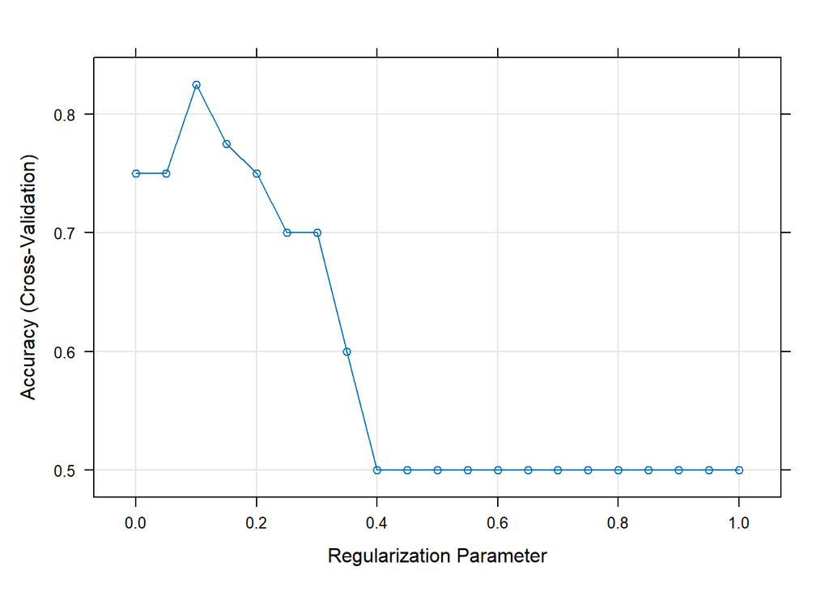

```r
control <- trainControl(method = "cv", number = 10)

metric <- "Accuracy"

fit.lasso <- train(ML~., data = dat, method = "glmnet",
                   family = "binomial",
                   tuneGrid = expand.grid(alpha = 1, lambda = seq(0, 1, by = 0.05)),
                   trControl = control,
                   metric = metric)

plot(fit.lasso)
```

## Comparing different classification methods

```r
fit.lda <- train(ML~., data = dat, method = "lda",
                 metric = metric, trControl = control)

fit.rf <- train(ML~., data = dat, method = "rf",
                metric = metric, trControl = control)

results <- resamples(list(RF = fit.rf, LDA = fit.lda, Lasso = fit.lasso))

summary(results)
```

```
##
## Call:
## summary.resamples(object = results)
##
## Models: RF, LDA, Lasso
## Number of resamples: 10
##
## Accuracy
##       Min. 1st Qu. Median  Mean 3rd Qu. Max. NA's
## RF     0.5    0.75  1.000 0.875       1    1    0
## LDA    0.5    0.75  0.875 0.850       1    1    0
## Lasso  0.5    0.75  0.750 0.825       1    1    0
##
## Kappa
##       Min. 1st Qu. Median Mean 3rd Qu. Max. NA's
## RF       0     0.5   1.00 0.75       1    1    0
## LDA      0     0.5   0.75 0.70       1    1    0
## Lasso    0     0.5   0.50 0.65       1    1    0
```

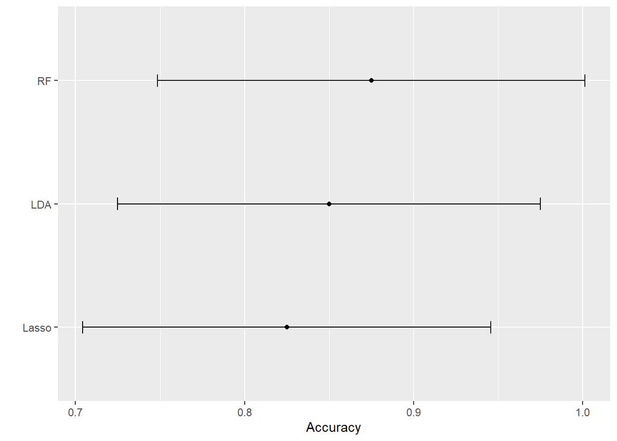

```r
ggplot(results) + labs(y = "Accuracy")
```

This graph represents the level of accuracy of different methods, used in this analysis.

## Scudo

```r
dat <- ex[, 1:40]

inTrain <- createDataPartition(f, list = FALSE)
trainData <- dat[, inTrain]
testData <- dat[, -inTrain]
```

### Analysing training set

```r
trainRes <- scudoTrain(trainData, groups = f[inTrain],
                       nTop = 25, nBottom = 25, alpha = 0.05)

trainRes
```

```
## Object of class ScudoResults
## Result of scudoTrain
##
## Number of samples      :  20
## Number of groups       :  2
##     0 :  10 samples
##     1 :  10 samples
## upSignatures length    :  25
## downSignatures length  :  25
## Fold-changes           :  computed
##     grouped            :  No
## Feature selection      :  performed
##     Test               :  Wilcoxon rank sum test
##     p-value cutoff     :  0.05
##     p.adjust method    :  none
##     Selected features  :  2851
```

### Inspecting signatures

```r
upSignatures(trainRes)[1:5, 1:5]
```

|  | GSM1060912 | GSM1060913 | GSM1060918 | GSM1060919 | GSM1060922 |
| --- | --- | --- | --- | --- | --- |
| 1 | 207802_at | 207802_at | 206799_at | 206799_at | 207802_at |
| 2 | 219795_at | 55616_at | 1569410_at | 226811_at | 225456_at |
| 3 | 213796_at | 223629_at | 207802_at | 235965_at | 225452_at |
| 4 | 206799_at | 221811_at | 216836_s_at | 206163_at | 206884_s_at |
| 5 | 55616_at | 219376_at | 235350_at | 202844_s_at | 227382_at |

```r
consensusUpSignatures(trainRes)[1:5, ]
```

|  | 0 | 1 |
| --- | --- | --- |
| 1 | 219858_s_at | 202882_x_at |
| 2 | 206667_s_at | 202018_s_at |
| 3 | 221207_s_at | 226848_at |
| 4 | 202604_x_at | 222528_s_at |
| 5 | 211936_at | 223180_s_at |

### Plotting map of training samples

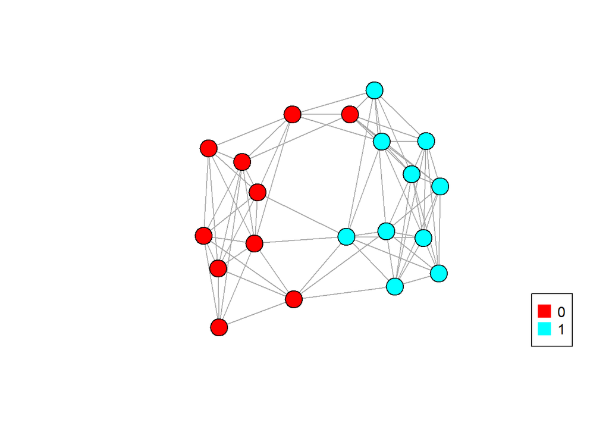

```r
trainNet <- scudoNetwork(trainRes, N = 0.4)
scudoPlot(trainNet, vertex.label = NA)
```

### Performing validation using testing samples

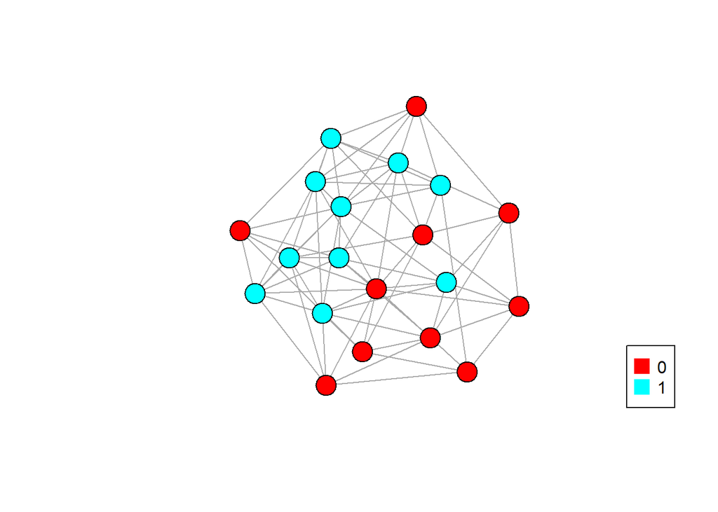

```r
testRes <- scudoTest(trainRes, testData, f[-inTrain],
                     nTop = 20, nBottom = 20)
testNet <- scudoNetwork(testRes, N = 0.4)
scudoPlot(testNet, vertex.label = NA)
```

### Clustering

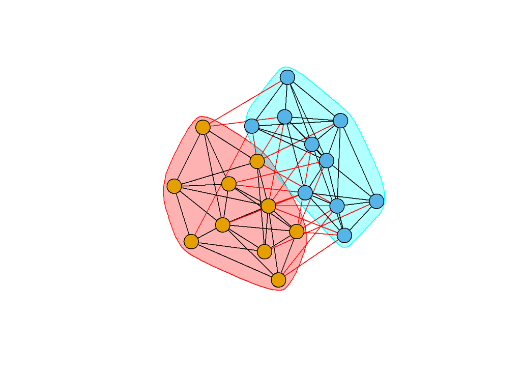

```r
testClust <- igraph::cluster_spinglass(testNet, spins = 2)
plot(testClust, testNet, vertex.label = NA)
```

```r
classRes <- scudoClassify(trainData, testData, N = 0.4,
                          nTop = 20, nBottom = 20,
                          trainGroups = f[inTrain], alpha = 0.05)
caret::confusionMatrix(classRes$predicted, f[-inTrain])
```

```
## Confusion Matrix and Statistics
##
##           Reference
## Prediction 0 1
##          0 9 3
##          1 1 7
##
##                Accuracy : 0.8
##                  95% CI : (0.5634, 0.9427)
##     No Information Rate : 0.5
##     P-Value [Acc > NIR] : 0.005909
##
##                   Kappa : 0.6
##
##  Mcnemar's Test P-Value : 0.617075
##
##             Sensitivity : 0.900
##             Specificity : 0.700
##          Pos Pred Value : 0.750
##          Neg Pred Value : 0.875
##              Prevalence : 0.500
##          Detection Rate : 0.450
##    Detection Prevalence : 0.600
##       Balanced Accuracy : 0.800
##
##        'Positive' Class : 0
##
```

## GOST

```r
gostres <- gost(query = c("X:1000:1000000",
                          "rs17396340",
                          "GO:0005005",
                          "ENSG00000156103",
                          "NLRP1"),
                organism = "hsapiens",
                ordered_query = FALSE,
                multi_query = FALSE,
                significant = TRUE,
                exclude_iea = FALSE,
                measure_underrepresentation = FALSE,
                evcodes = FALSE,
                user_threshold = 0.05,
                correction_method = "g_SCS",
                domain_scope = "annotated",
                custom_bg = NULL,
                numeric_ns = "",
                sources = NULL,
                as_short_link = FALSE)
```

```r
names(gostres)
```

```
## [1] "result" "meta"
```

```r
head(gostres$result)
```

|  | query | significant | p_value | term_size | query_size | intersection_size | precision | recall | term_id | source | term_name | effective_domain_size | source_order | parents |
| --- | --- | --- | --- | --- | --- | --- | --- | --- | --- | --- | --- | --- | --- | --- |
| 1 | query_1 | TRUE | 4.998799e-02 | 1 | 3 | 1 | 0.3333333 | 1.00000000 | CORUM:6180 | CORUM | PPP2R1A-PPP2R3B complex | 3383 | 1952 |  |
| 2 | query_1 | TRUE | 2.115706e-30 | 51 | 20 | 14 | 0.7000000 | 0.27450980 | GO:0048013 | GO:BP | ephrin receptor signaling pathway | 21031 | 12892 |  |
| 3 | query_1 | TRUE | 7.617347e-18 | 249 | 20 | 13 | 0.6500000 | 0.05220884 | GO:0097485 | GO:BP | neuron projection guidance | 21031 | 19215 |  |
| 4 | query_1 | TRUE | 7.617347e-18 | 249 | 20 | 13 | 0.6500000 | 0.05220884 | GO:0007411 | GO:BP | axon guidance | 21031 | 2940 |  |
| 5 | query_1 | TRUE | 1.573024e-14 | 616 | 20 | 14 | 0.7000000 | 0.02272727 | GO:0007169 | GO:BP | transmembrane receptor protein tyrosine kinase signaling pathway | 21031 | 2764 |  |
| 6 | query_1 | TRUE | 2.855428e-14 | 466 | 20 | 13 | 0.6500000 | 0.02789700 | GO:0007409 | GO:BP | axonogenesis | 21031 | 2939 |  |

```r
p <- gostplot(gostres,
              capped = TRUE,
              interactive = FALSE)
```

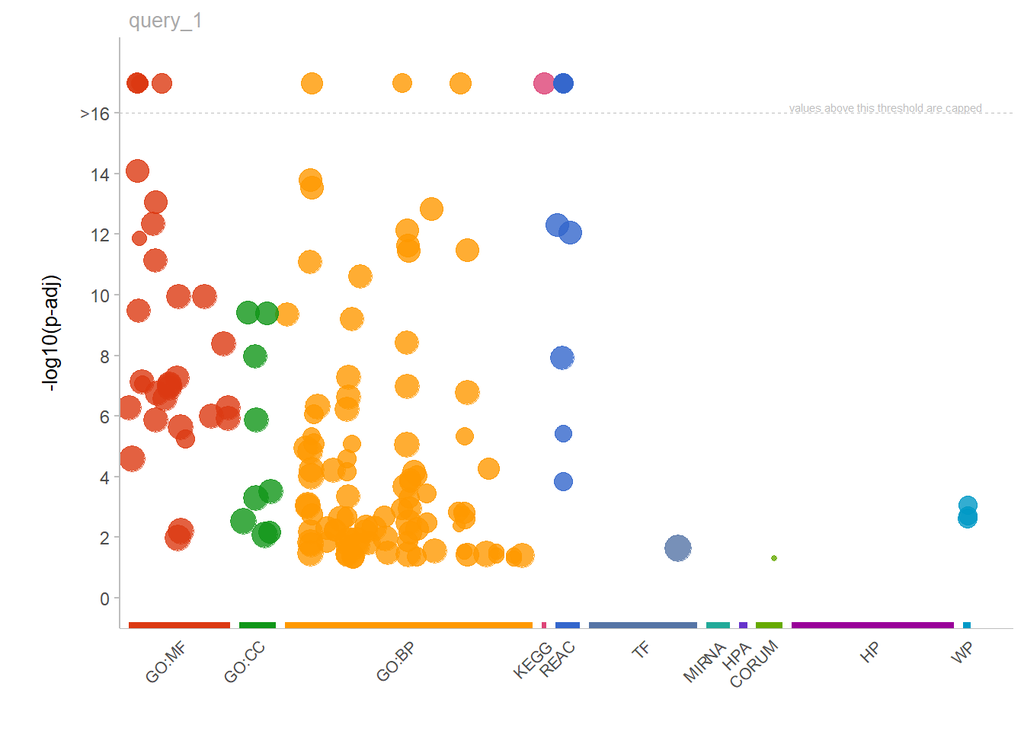

```r
publish_gostplot(p,
                #highlight_terms = c("GO:0048013", "REAC:R-HSA-3928663")
                 width = NA, height = NA)
```